# LIVER DISEASE PROJECT

Dennis Mugendi

21/09/2021

## Loading the needed packages

```r
library(psych)
library(ggplot2)
library(caret)
library(VIM)
library(mice)
library(kernlab)
library(randomForest)
library(caretEnsemble)
library(shiny)
library(shinydashboard)
```

Loading the Indian Liver Disease data set.

```r
liver_data<-read.csv("C:/Users/adm/Documents/Datasets/Indian Liver Patient Dataset (ILPD).csv")
```

## Taking a glance at the data

### Head

```r
head(liver_data)
```

```
##   age gender tot_bilirubin direct_bilirubin tot_proteins albumin ag_ratio sgpt
## 1  65 Female           0.7              0.1          187      16       18  6.8
## 2  62   Male          10.9              5.5          699      64      100  7.5
## 3  62   Male           7.3              4.1          490      60       68  7.0
## 4  58   Male           1.0              0.4          182      14       20  6.8
## 5  72   Male           3.9              2.0          195      27       59  7.3
## 6  46   Male           1.8              0.7          208      19       14  7.6
##   sgot alkphos is_patient
## 1  3.3    0.90          1
## 2  3.2    0.74          1
## 3  3.3    0.89          1
## 4  3.4    1.00          1
## 5  2.4    0.40          1
## 6  4.4    1.30          1
```

### Summary

```r
summary(liver_data)
```

```
##       age           gender          tot_bilirubin    direct_bilirubin
##  Min.   : 4.00   Length:583         Min.   : 0.400   Min.   : 0.100
##  1st Qu.:33.00   Class :character   1st Qu.: 0.800   1st Qu.: 0.200
##  Median :45.00   Mode  :character   Median : 1.000   Median : 0.300
##  Mean   :44.75                      Mean   : 3.299   Mean   : 1.486
##  3rd Qu.:58.00                      3rd Qu.: 2.600   3rd Qu.: 1.300
##  Max.   :90.00                      Max.   :75.000   Max.   :19.700
##
##   tot_proteins       albumin           ag_ratio           sgpt
##  Min.   :  63.0   Min.   :  10.00   Min.   :  10.0   Min.   :2.700
##  1st Qu.: 175.5   1st Qu.:  23.00   1st Qu.:  25.0   1st Qu.:5.800
##  Median : 208.0   Median :  35.00   Median :  42.0   Median :6.600
##  Mean   : 290.6   Mean   :  80.71   Mean   : 109.9   Mean   :6.483
##  3rd Qu.: 298.0   3rd Qu.:  60.50   3rd Qu.:  87.0   3rd Qu.:7.200
##  Max.   :2110.0   Max.   :2000.00   Max.   :4929.0   Max.   :9.600
##
##       sgot          alkphos         is_patient
##  Min.   :0.900   Min.   :0.3000   Min.   :1.000
##  1st Qu.:2.600   1st Qu.:0.7000   1st Qu.:1.000
##  Median :3.100   Median :0.9300   Median :1.000
##  Mean   :3.142   Mean   :0.9471   Mean   :1.286
##  3rd Qu.:3.800   3rd Qu.:1.1000   3rd Qu.:2.000
##  Max.   :5.500   Max.   :2.8000   Max.   :2.000
##                  NA's   :4
```

# Data Exploration

```r
str(liver_data)
```

```
## 'data.frame':    583 obs. of  11 variables:
##  $ age             : int  65 62 62 58 72 46 26 29 17 55 ...
##  $ gender          : chr  "Female" "Male" "Male" "Male" ...
##  $ tot_bilirubin   : num  0.7 10.9 7.3 1 3.9 1.8 0.9 0.9 0.9 0.7 ...
##  $ direct_bilirubin: num  0.1 5.5 4.1 0.4 2 0.7 0.2 0.3 0.3 0.2 ...
##  $ tot_proteins    : int  187 699 490 182 195 208 154 202 202 290 ...
##  $ albumin         : int  16 64 60 14 27 19 16 14 22 53 ...
##  $ ag_ratio        : int  18 100 68 20 59 14 12 11 19 58 ...
##  $ sgpt            : num  6.8 7.5 7 6.8 7.3 7.6 7 6.7 7.4 6.8 ...
##  $ sgot            : num  3.3 3.2 3.3 3.4 2.4 4.4 3.5 3.6 4.1 3.4 ...
##  $ alkphos         : num  0.9 0.74 0.89 1 0.4 1.3 1 1.1 1.2 1 ...
##  $ is_patient      : int  1 1 1 1 1 1 1 1 2 1 ...
```

Using the `str()` i analyzed the basic structure of the data.The data has 11 variables and 583 observations The response variable is is_patient which is an integer value with values 1 and 2.2indicates patient with liver disease while 1 represents patients without liver disease.Gender is a `chr()` with two levels male and females, while other variables are int and nun datatypes.

- **Convert gender to factor**

```
liver_data$gender<-as.factor(liver_data$gender)
```

Further descriptive data analysis.

```r
d<-describeBy(liver_data)
d
```

```
##                  vars   n   mean     sd median trimmed   mad  min    max  range
## age                 1 583  44.75  16.19  45.00   44.84 17.79  4.0   90.0   86.0
## gender*             2 583   1.76   0.43   2.00    1.82  0.00  1.0    2.0    1.0
## tot_bilirubin       3 583   3.30   6.21   1.00    1.74  0.44  0.4   75.0   74.6
## direct_bilirubin    4 583   1.49   2.81   0.30    0.74  0.30  0.1   19.7   19.6
## tot_proteins        5 583 290.58 242.94 208.00  238.40 74.13 63.0 2110.0 2047.0
## albumin             6 583  80.71 182.62  35.00   43.91 22.24 10.0 2000.0 1990.0
## ag_ratio            7 583 109.91 288.92  42.00   56.79 31.13 10.0 4929.0 4919.0
## sgpt                8 583   6.48   1.09   6.60    6.51  1.04  2.7    9.6    6.9
## sgot                9 583   3.14   0.80   3.10    3.15  0.89  0.9    5.5    4.6
## alkphos            10 579   0.95   0.32   0.93    0.93  0.25  0.3    2.8    2.5
## is_patient         11 583   1.29   0.45   1.00    1.23  0.00  1.0    2.0    1.0
##                   skew kurtosis    se
## age              -0.03    -0.57  0.67
## gender*          -1.19    -0.58  0.02
## tot_bilirubin     4.88    36.70  0.26
## direct_bilirubin  3.20    11.20  0.12
## tot_proteins      3.75    17.52 10.06
## albumin           6.52    49.95  7.56
## ag_ratio         10.49   149.10 11.97
## sgpt             -0.28     0.21  0.04
## sgot             -0.04    -0.40  0.03
## alkphos           0.99     3.22  0.01
## is_patient        0.94    -1.11  0.02
```

From the skew values its evident that there is skewness present in the data.The features like Aspartate_Aminotransferase and Alamine_Aminotransferase. The mean trimmed value which indicates the mean of a data set by trimming outliers,is widely different from the actual mean indicating presence of outliers

# Exploratory Data plots

```r
temp<-liver_data
temp$is_patient<-as.factor(liver_data$is_patient)
temp$gender<-as.numeric(temp$gender)
```

## Piechart

**Plotting pie chart of attribute is_patient:**

```r
mytable<-table(temp$is_patient)
mytable
```

```
##
##   1   2
## 416 167
```

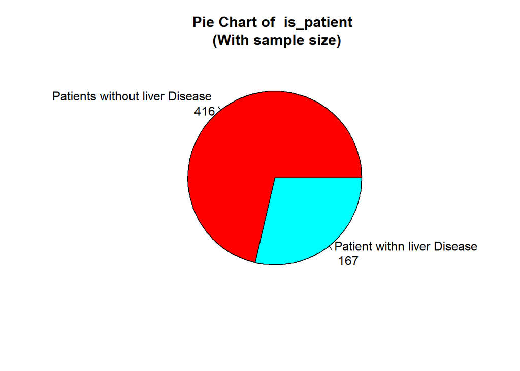

```r
lbs<-c("Patients without liver Disease","Patient withn liver Disease")
lbs<-paste(lbs, "\n", mytable)
pie(mytable,labels = lbs,
    main="Pie Chart of  is_patient \n (With sample size)",
    col = rainbow(length(lbs)))
```

## Histogram

**Plotting Histogram of Attribute Gender w.r.t to Response attribute is_patient:**

[figure not shown]

```r
ggplot(data = temp,aes(x=gender))+
  geom_histogram(barwidth=1.2,color="black",aes(fill=is_patient),position = "dodge")+
  xlab("Gender")+
  ylab("Is_patient")+
  ggtitle("Histogram of Gender")
```

**Further exploring the skewness of the data by plotting a histogram**

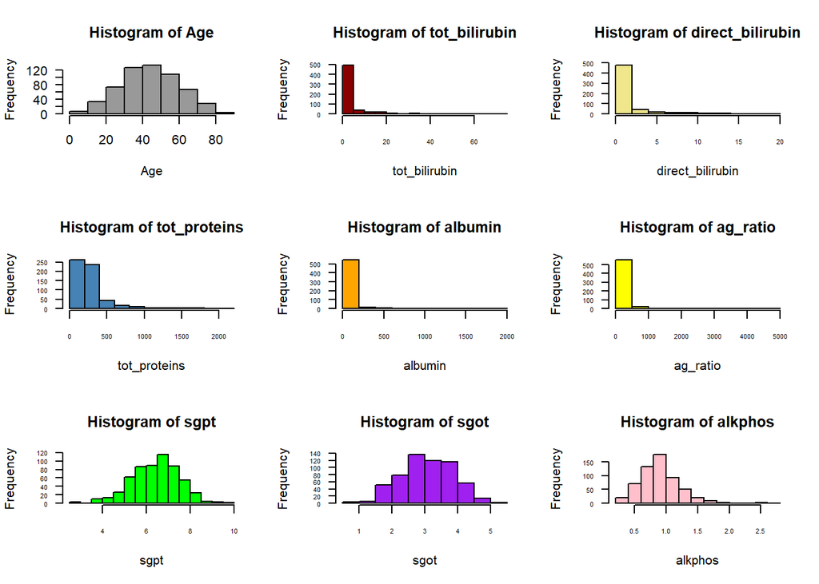

```r
par(mfrow=c(3,3))
col_hist<-c("darkred","khaki","steelblue","orange","yellow","green","purple","pink")
hist(liver_data$age,col = "#999999",border = "black",las=1,xlab = "Age",
     main = "Histogram of Age")
#Plotting for all features
for (i in 3:10) {
  hist(liver_data[,i],cex.axis=.5,col = col_hist[i-2],las=1,xlab = names(liver_data)[i],
       main = paste("Histogram of",names(liver_data)[i]))

}
```

High right skewness is present in features Alkaline phosphates,total bilirubin,alamine aminostransfer,Direct bilirubin and aspartate aminotranfe

*Alternatively Visualizing the data using ggplot*

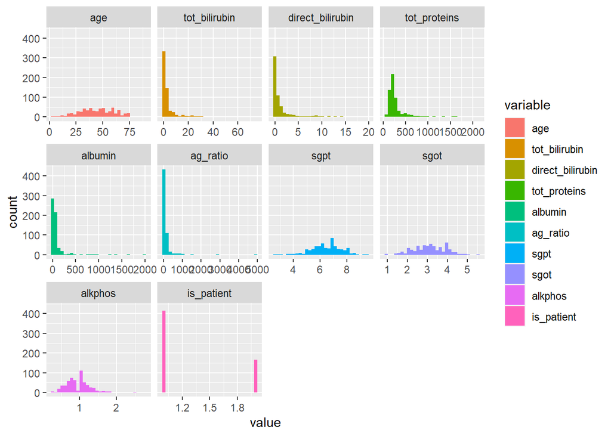

```r
library(reshape2)
ggplot(data = melt(liver_data),mapping = aes(x=value,fill=variable))+
  geom_histogram(bins = 30)+
  facet_wrap(~variable,scales = "free_x")
```

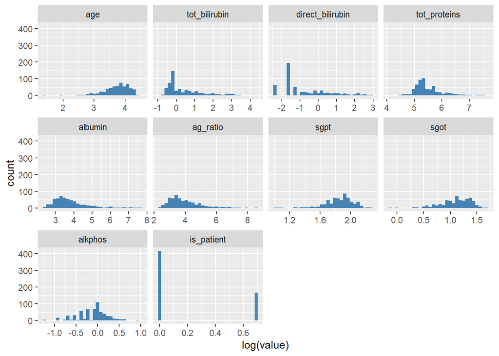

```r
ggplot(data = melt(liver_data),mapping = aes(x=log(value),fill=variable))+
  geom_histogram(bins = 30,fill="steelblue")+
  facet_wrap(~variable,scales = "free_x")
```

There was some slight improvement in the data.Log transformation won’t be of much use here

# Density plot

## Denisty Plot A

Density plot for each attribute by class value shows the distribution of the data for each attribute with respect to feature *is_patient. Density plot for the first 5 attributes.

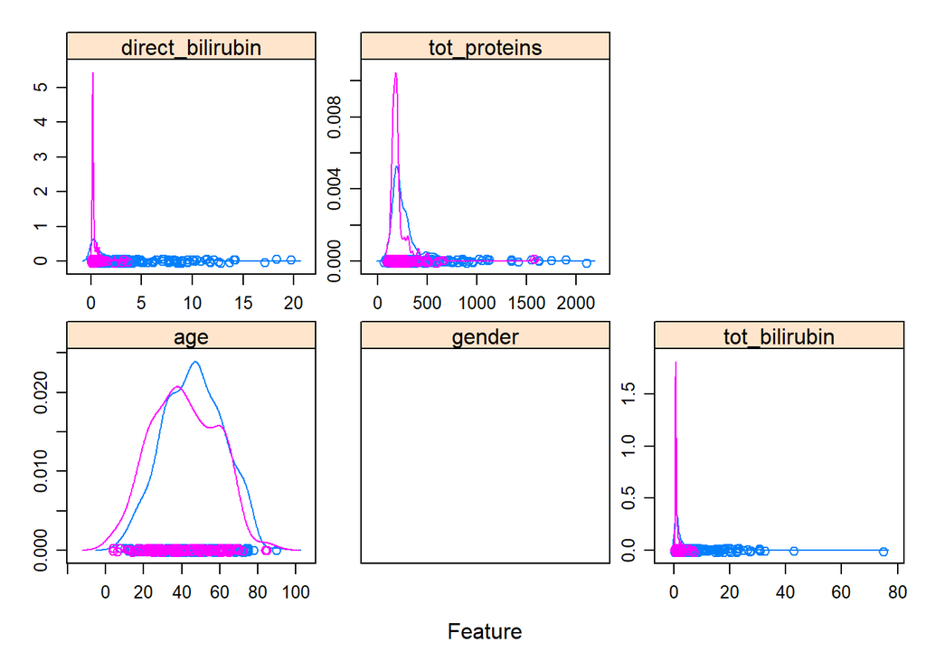

```r
x<-temp[,1:5]
y<-temp[,11]
scales<-list(x=list(relation="free"),y=list(relation="free"))
featurePlot(x=x,y=y,plot = "density",scales=scales)
```

## Density plot B

Density plot for the last 5 attributes

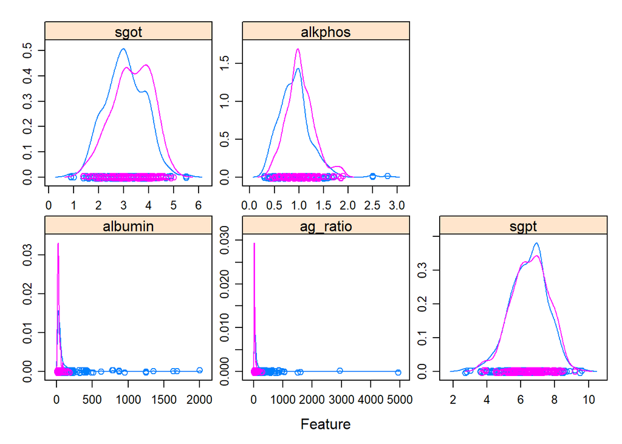

```r
xx<-temp[,6:10]
y<-temp[,11]
scales<-list(x=list(relation="free"),y=list(relation="free"))
featurePlot(x=xx,y=y,plot = "density",scales=scales)
```

The pink Density graph indicates a density plot wit features with liver disease and blue indicates features without liver disease

*Analyzing the distribution of age w.r.t response variable using boxplot and mapping a jitter over it*

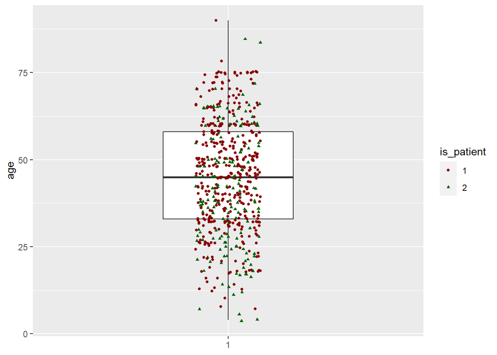

```r
ggplot(temp,aes(x=factor(1),y=age))+
  geom_boxplot(width=0.4,fill="white")+
  geom_jitter(aes(color=is_patient,shape=is_patient),
              width = 0.1,size=1)+
  scale_color_manual(values=c("darkred","darkgreen"))+
  labs(x=NULL)
```

## **Detecting outliers**

**Using Box plots to analyze outliers**

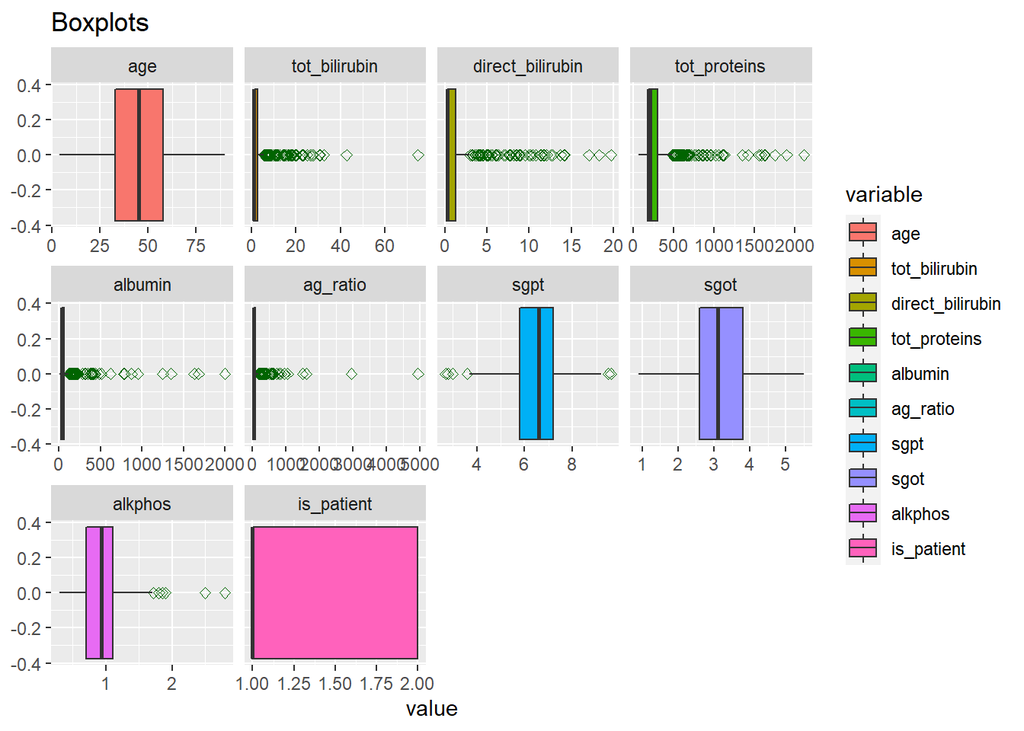

```r
par(mfrow=c(2,2))
ggplot(data = melt(liver_data),aes(x=value,fill=variable))+
  geom_boxplot(outlier.colour = "darkgreen",outlier.shape = 5)+
  scale_color_brewer(palette = "Dark2")+
  facet_wrap(~variable,scales = "free_x")+
  labs(title = "Boxplots")
```

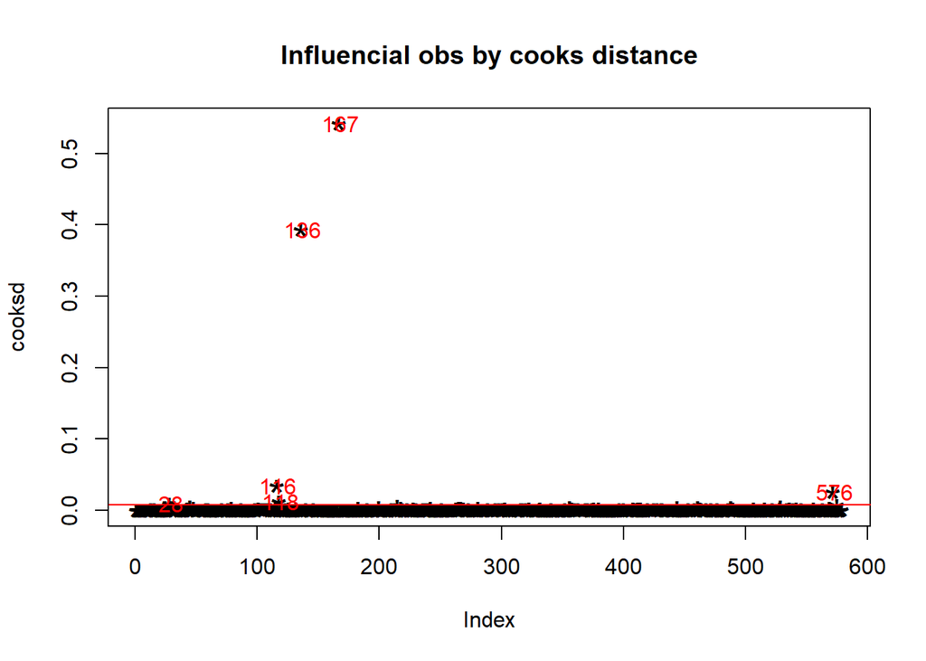

```r
mod<-glm(is_patient~.,data = liver_data)
cooksd<-cooks.distance(mod)

plot(cooksd,pch="*",cex=2,main = "Influencial obs by cooks distance")
abline(h=3*mean(cooksd,na.rm = T),col="red")
text(x=1:length(cooksd)+1,y=cooksd,labels = ifelse(cooksd>3*mean(cooksd,na.rm=T),names(cooksd),""),
col="red")
```

## Correlation and colinearity analysis

Using the *scatter plot matrix*

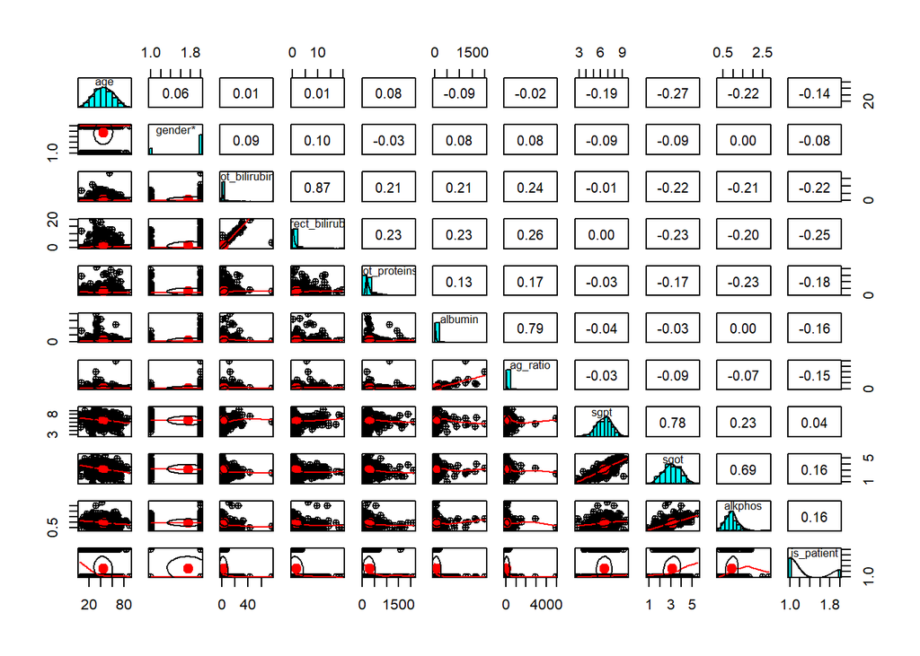

```r
pairs.panels(liver_data,pch = 10)
```

Plotting for a more clearer view

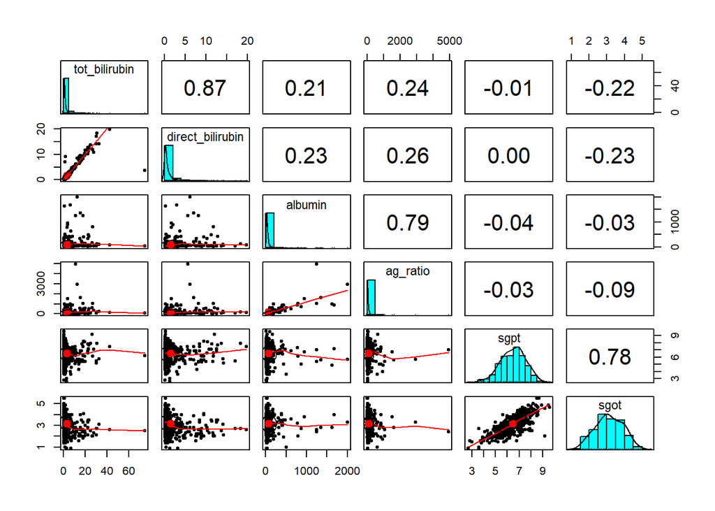

```r
pairs.panels(liver_data[c(3,4,6,7,8,9)])
```

The bottom part shows scatter plots of different features

Plotting a scatter plot of *total bilirubin vs direct_bilirubin*

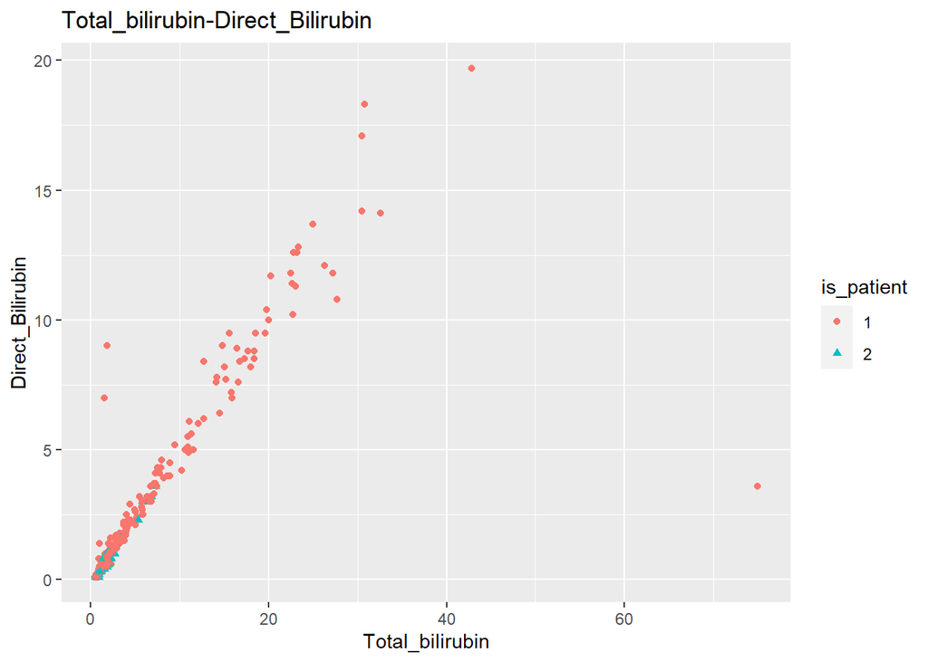

```r
ggplot(data = temp,aes(x=tot_bilirubin,y=direct_bilirubin))+
  geom_point(aes(color=is_patient,shape=is_patient))+
  labs(x="Total_bilirubin",y="Direct_Bilirubin",title = "Total_bilirubin-Direct_Bilirubin")
```

## Analyzing the missing values ins the dataset

```r
table(is.na(liver_data))
```

```
##
## FALSE  TRUE
##  6409     4
```

```r
sapply(liver_data,function(x)sum(is.na(x)))#Number of missing values for each feature.
```

```
##              age           gender    tot_bilirubin direct_bilirubin
##                0                0                0                0
##     tot_proteins          albumin         ag_ratio             sgpt
##                0                0                0                0
##             sgot          alkphos       is_patient
##                0                4                0
```

**Visualizing the missing values**

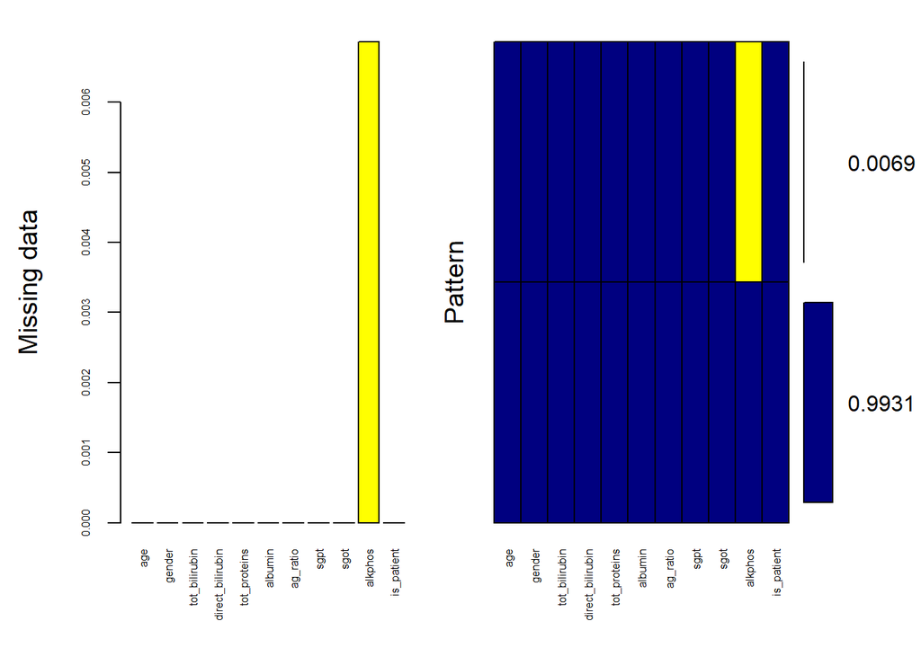

```r
missing_plot<-aggr(liver_data,col=c("navyblue","yellow"),numbers=T,sortvars=TRUE,
                  labels=names(liver_data),cex.axis=.5,gap=3,ylab=c("Missing data","Pattern"))
```

I have visualized a pattern of missing values and noticed 99.31% of data is complete